# Lucas & Kemp replication

A replication of [Lucas & Kemp, 2015](http://philpapers.org/archive/LUCAIP.pdf), including additional conditions with explanations.

## Model

L&K used a simple grid search to find parameter values that minimized sum squared error. They considered considered 1000 uniformly spaced parameter values between 0 and 1. Best-fit parameter was s=0.68.

## Basic method

#### First slide (my words):

We will give you descriptions of different labs that are studying hormones in rats.

Different labs are studying different hormones, so the hormone that one lab calls “A” will not be the same hormone that another lab calls “A”.

#### Subsequent slides:

Present short story.

In random order, present questions.

e.g.

> If hormone A were observed to be absent, would hormone A be present?  
> Yes  
> No  
> How confident are you in your answer?  
> Not at all confident  
> Completely confident

L&K converted these ratings to subjective probabilities by treating “Not at all confident” responses as 0.5 and linearly interpolating between 0.5 and either 0 or 1, where the direction of interpolation depended on the answer to the yes/no question.

#### Last slide:

To get prior probabilities, at the end of each experiment, L&K asked,

> How many, out of 100 mice, does ‘a very small number’ correspond to?

and rounded the median to the nearest multiple of 5.

These kinds of questions were included as attention checks:

- If you had observed hormone A to be present, would hormone A be present?

Participants who answered these questions incorrectly were excluded.

## Causal stories

### Story 1: no relation, observation

#### Causal structure

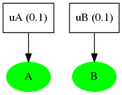

#### Background (story)

##### {{Tondam}} Lab

The {{Tondam}} Lab is studying hormones in rats. They found two hormones in their rats and called them hormone A and hormone B.

> In a very small number of the mice, hormone A is present.

> In a very small number of the mice, hormone B is present.

> The presence or absence of hormone A does not depend on the status of hormone B.

> The presence or absence of hormone B does not depend on the status of hormone A.

> {{Fred}} is a mouse from the {{Tondam}} Lab. You test {{Fred}} and find that:
> - Hormone A is definitely present.
> - Hormone B is definitely present.

#### Questions

- For {{Fred}} the mouse, if you had observed A to be absent, would A be present?
- For {{Fred}} the mouse, if you had observed A to be absent, would B be present?

#### L&K original findings

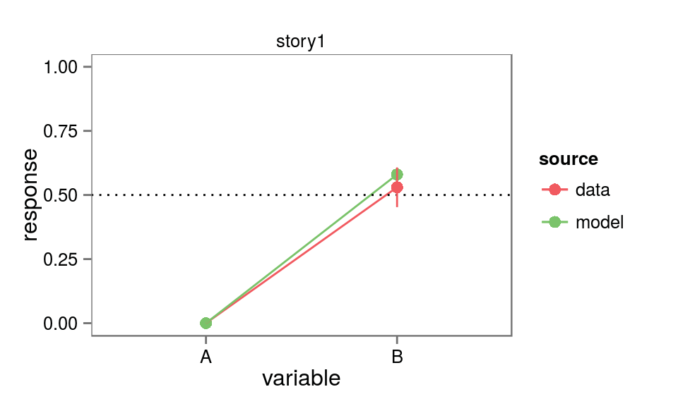

#### Replication results

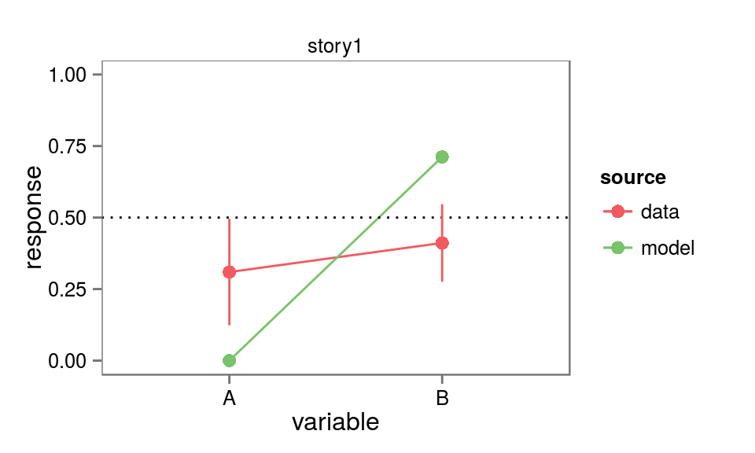

#### “Replication” with explanations

- For {{Fred}} the mouse, B is present because .
- For {{Fred}} the mouse, A is present because .

(base counterfactual)

### Story 2: causal chain

#### Causal structure

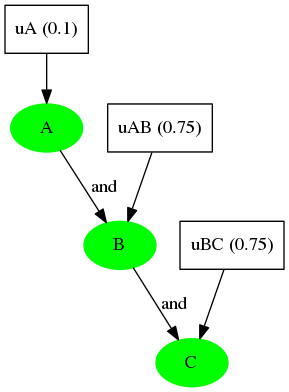

#### Background (story)

##### {{Nanber}} Lab

The {{Nanber}} Lab is studying hormones in rats. They found three hormones in their rats and called them hormone A, hormone B, and hormone C.

> In almost all of the mice, hormone A is absent.

> The status of hormone B is caused by the status of hormone A and nothing else.

> In many of the mice, if A is present, this causes B to be present.

> The status of hormone C is caused by the status of hormone B and nothing else.

> In many of the mice, if B is present, this causes C to be present.

> {{Frank}} is a mouse from the {{Nanber}} Lab. You test {{Frank}} and find that:
> - Hormone A is definitely present.
> - Hormone B is definitely present.
> - Hormone C is definitely present.

#### Questions

- For {{Frank}} the mouse, if you had observed B to be absent, would A be present?
- For {{Frank}} the mouse, if you had observed B to be absent, would B be present?
- For {{Frank}} the mouse, if you had observed B to be absent, would C be present?

#### L&K original findings

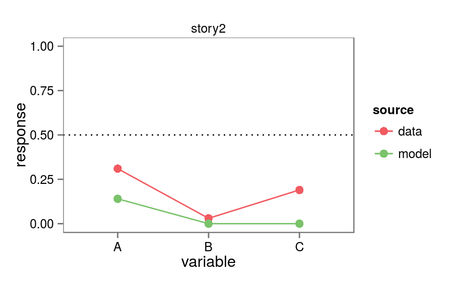

#### Replication results

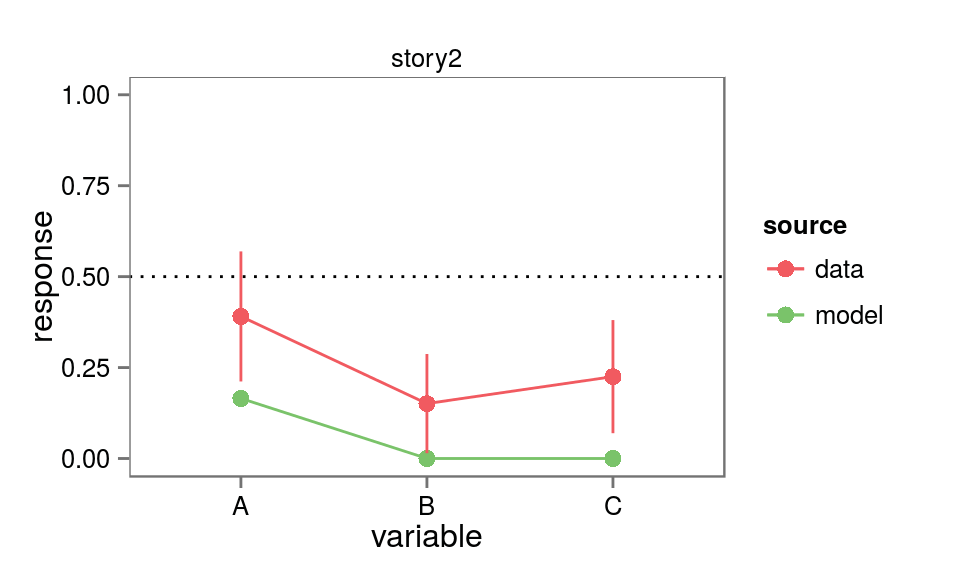

#### “Replication” with explanations

- For {{Frank}} the mouse, A is present because .
- For {{Frank}} the mouse, B is present because .
- For {{Frank}} the mouse, C is present because .

### Story 3: simple

#### Causal structure

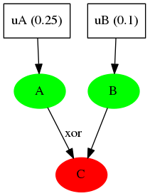

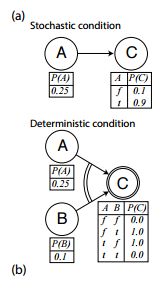

#### Background (story) A: stochastic

##### {{Gostak}} Lab

> The {{Gostak}} Lab is studying hormones in rats. They found two hormones in their rats and called them hormone A and hormone B.

> In some of the mice, hormone A is present.

> The status of hormone B is caused by the status of hormone A and nothing else.

> In a very small number of the mice, if A is present, this causes B to be absent, and if A is absent, this causes B to be present.

> In the remaining mice, if A is present, this causes B to be present, and if A is absent, this causes B to be absent.

> {{Ronald}} is a mouse from the {{Gostak}} Lab. You test {{Ronald}} and find that:
> - Hormone A is definitely present.
> - Hormone B is definitely not present.

#### Questions A

- For {{Ronald}} the mouse, if A were absent, would A be present?
- For {{Ronald}} the mouse, if A were absent, would B be present?

#### Background (story) B: deterministic

##### {{Muckenhoupt}} Lab

> The {{Muckenhoupt}} Lab is studying hormones in rats. They found three hormones in their rats and called them hormone A, hormone B, and hormone C.

> In some of the mice, hormone A is present.

> In a very small number of the mice, hormone B is present.

> The status of hormone C is caused by the status of hormones A and B and nothing else.

> If B is absent, this causes C’s status to match A’s: if A is present, this causes C to be present, and if A is absent, this causes C to be absent.

> If B is present, this causes C’s status to be the opposite of A’s: if A is present, this causes C to be absent, and if A is absent, this causes C to be present.

> {{Florence}} is a mouse from the {{Muckenhoupt}} Lab.

> You test {{Florence}} and find that:
> - Hormone A is definitely present.
> - Hormone C is definitely not present.

#### Questions B

- For {{Florence}} the mouse, if A were absent, would A be present?
- For {{Florence}} the mouse, if A were absent, would B be present?
- For {{Florence}} the mouse, if A were absent, would C be present?

#### L&K original findings

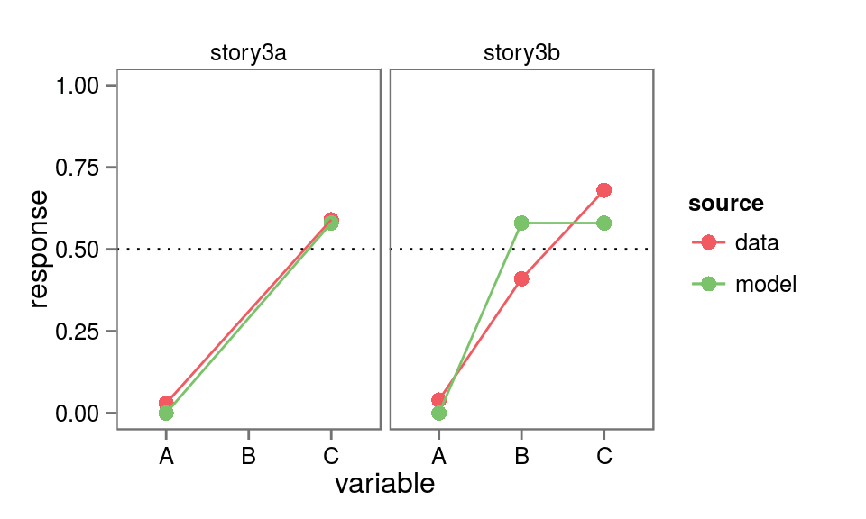

#### Replication results

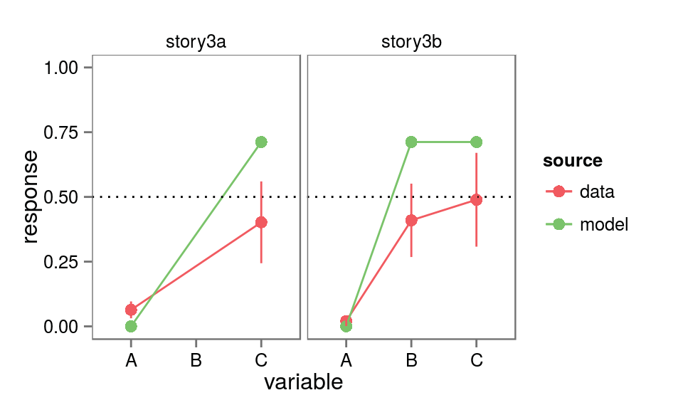

#### “Replication” with explanations

- For {{Ronald}} the mouse, B is not present because .
- For {{Ronald}} the mouse, A is present because .
- For {{Florence}} the mouse, A is present because .
- For {{Florence}} the mouse, B is present because .
- For {{Florence}} the mouse, C is not present because .

### Story 4: equally strong causes

#### Causal structure

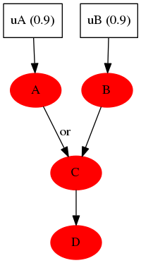

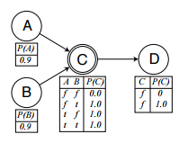

#### Background (story)

##### {{Weyland}} Lab

The {{Weyland}} Lab is studying hormones in rats. They found four hormones in their rats and called them hormone A, hormone B, hormone C, and hormone D.

> In almost all of the mice, hormone A is present.

> In almost all of the mice, hormone B is present.

> The status of hormone C is caused by the status of hormones A and B and nothing else.

> If A is present, this always causes C to be present.

> If B is present, this always causes C to be present.

> The status of hormone D is caused by the status of hormone C and nothing else.

> If C is present, this always causes D to be present.

> {{Harold}} is a mouse from the {{Weyland}} Lab. You test {{Harold}} and find that:
> - Hormone A is definitely not present.
> - Hormone B is definitely not present.
> - Hormone C is definitely not present.
> - Hormone D is definitely not present.

#### Questions

- For {{Harold}} the mouse, if C were present, would A be present?
- For {{Harold}} the mouse, if C were present, would B be present?
- For {{Harold}} the mouse, if C were present, would C be present?
- For {{Harold}} the mouse, if C were present, would D be present?

#### L&K original findings

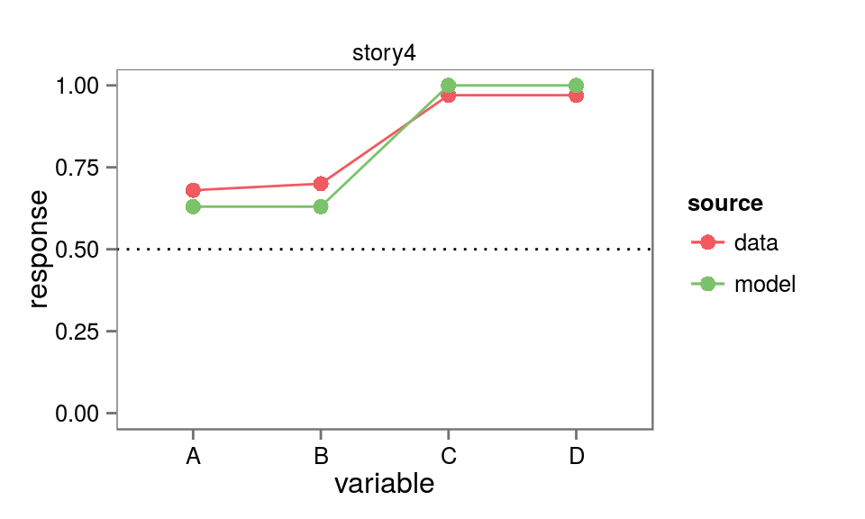

#### Replication results

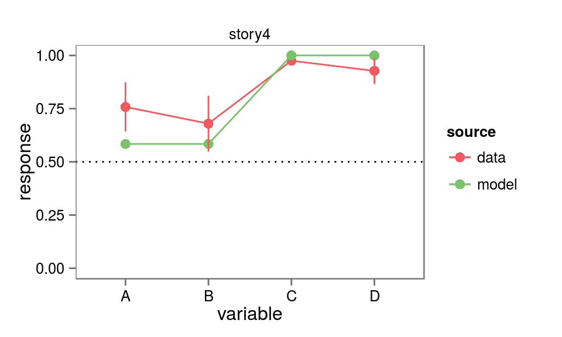

#### “Replication” with explanations

- For {{Harold}} the mouse, A is not present because .
- For {{Harold}} the mouse, B is not present because .
- For {{Harold}} the mouse, C is not present because .
- For {{Harold}} the mouse, D is not present because .

### Story 5: different strength causes

#### Causal structure

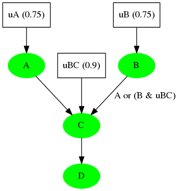

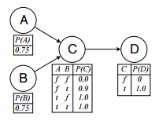

#### Background (story)

##### {{Snarp}} Lab

> In many of the mice, hormone A is present.

> In many of the mice, hormone B is present.

> The status of hormone C is caused by the status of hormones A and B and nothing else.

> If hormone A is present, this always causes hormone C to be present.

> If hormone B is present, this almost always causes hormone C to be present.

> The presence of hormone D is caused by the presence of hormone C.

> If hormone C is present, this always causes hormone D to be present.

> {{Ilana}} is a mouse from the {{Snarp}} Lab. You test {{Ilana}} and find that:
> - Hormone A is definitely present.
> - Hormone B is definitely present.
> - Hormone C is definitely present.
> - Hormone D is definitely present.

#### Questions

- For {{Ilana}} the mouse, if C were absent, would A be present?
- For {{Ilana}} the mouse, if C were absent, would B be present?
- For {{Ilana}} the mouse, if C were absent, would C be present?
- For {{Ilana}} the mouse, if C were absent, would D be present?

#### L&K original findings

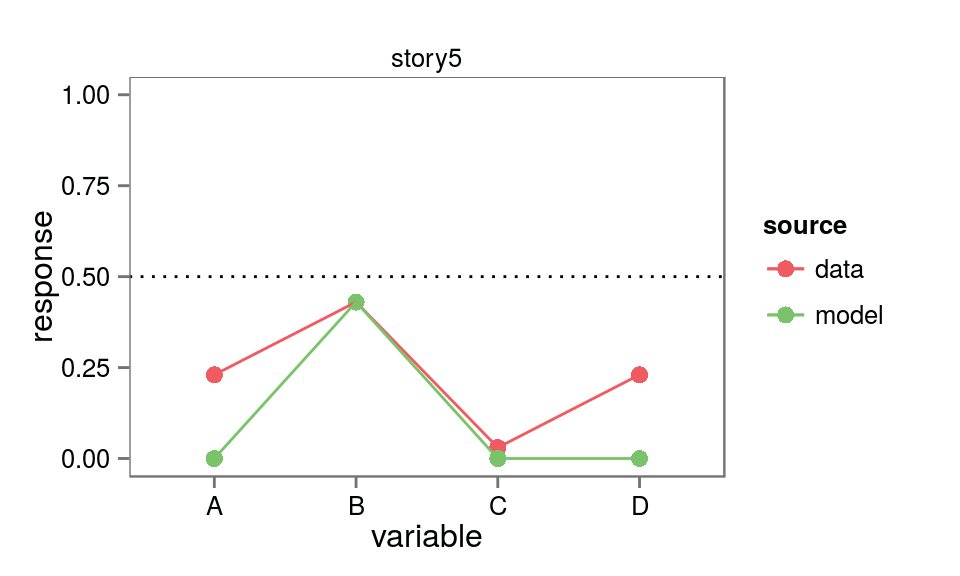

#### Replication results

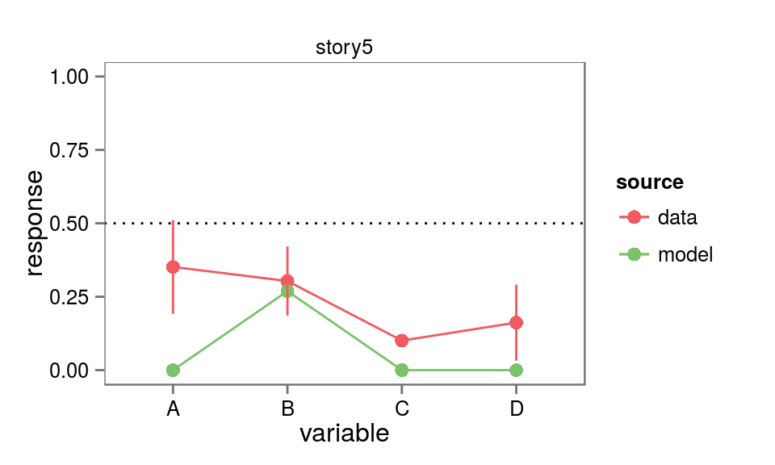

#### “Replication” with explanations

- For {{Ilana}} the mouse, A is present because .
- For {{Ilana}} the mouse, B is present because .
- For {{Ilana}} the mouse, C is present because .
- For {{Ilana}} the mouse, D is present because .

### Story 6: xor chain

#### Causal structure

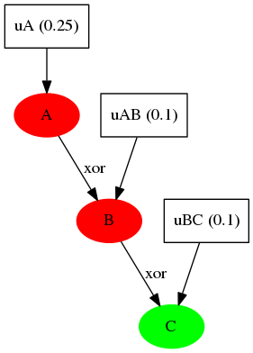

#### Background (story)

##### {{Wrean}} Lab

The {{Wrean}} Lab is studying hormones in rats. They found three hormones in their rats and called them hormone A, hormone B, and hormone C.

> In some of the mice, hormone A is present.

> The status of hormone B is caused by the status of hormone A and nothing else.

> In almost all mice, if A is present, this causes B to be present, and if A is absent, this causes B to be absent. In the remaining mice, if A is present, this causes B to be absent, and if A is absent, this causes B to be present.

> The status of hormone C is caused by the status of hormone B and nothing else.

> In almost all mice, if B is present, this causes C to be present, and if B is absent, this causes C to be absent. In the remaining mice, if B is present, this causes C to be absent, and if B is absent, this causes C to be present.

> {{Albert}} is a mouse from the {{Wrean}} Lab. You test {{Albert}} and find that:
> - Hormone A is definitely not present.
> - Hormone B is definitely not present.
> - Hormone C is definitely present.

#### Questions

- For {{Albert}} the mouse, if you had observed B to be present, would A be present?
- For {{Albert}} the mouse, if you had observed B to be present, would B be present?
- For {{Albert}} the mouse, if you had observed B to be present, would C be present?

#### L&K original findings

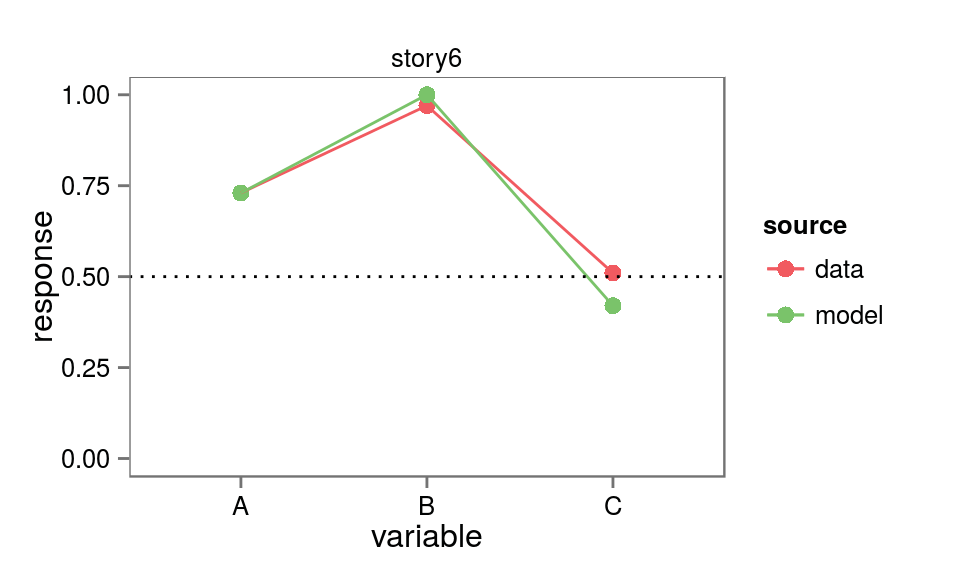

#### Replication results

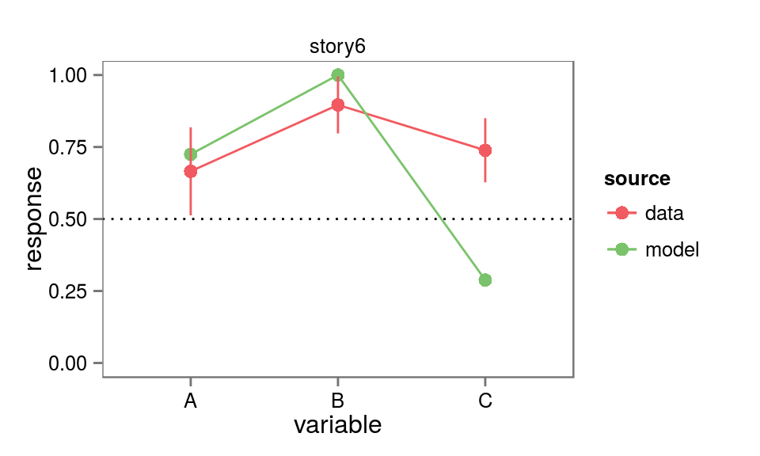

#### “Replication” with explanations

- For {{Albert}} the mouse, A is not present because .
- For {{Albert}} the mouse, B is not present because .
- For {{Albert}} the mouse, C is present because .

## Overall replication results (counterfactual)

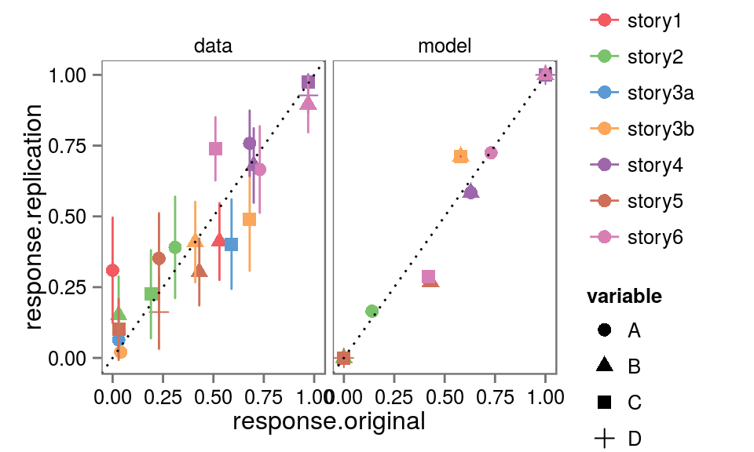

## Demographic information (counterfactual)

```
## [1] "comments:"
## [1] ""
## [2] "It was tough but I enjoyed it."
## [3] "I was slightly uncertain of what was meant by questions such as: \"If Hormone A is observed to be present, is Hormone A present?\" It seems straightforward but then also strange to be asked repeatedly. I hope my interpretation of those questions were correct."
## [4] "The instructions were ok but did get long towards some of the studies which could get a little confusing trying to keep it all straight. "
## [5] "I read the instructions and I think I did the hit correctly but I am not very sure. "
## [6] "I really enjoyed it!"
## [7] "It was a little bit confusing. I hope I did everything correctly."
## [8] "this was very interesting! I didn&quotechart really understand the \"if A was present, would A also be present\" type questions, because they seemed either very obvious or secretly tricky"
## [9] "none"
## [1] "number of participants:  20"
```

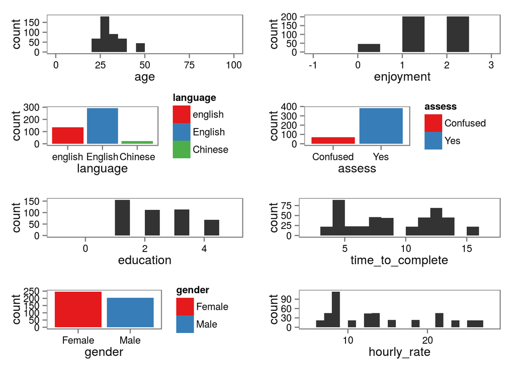

## ToDo

3. get model predictions & graph them
4. compare replication to L&K, i.e.
   - compare the statistics they reported to ours
   - check that their model predictions match ours
5. email noah results
   - should I run more Ss (They ran 56 on Turk, I ran 20 for $35.70)
6. explanations?